# Geospatial Services Menu

A guide to Geospatial data, methods and Geographic Information Systems

- Leverage Geospatial Services to enrich your existing data with contextual and derived geographic data.
- Generate advanced geographic or location-based data metrics for your analysis.

### Contact

Mount Sinai  
3 E 101st St.  
2nd Floor  
New York, NY, 10029  
daniel.sheehan@mountsinai.org

# Table of Contents

```python
import os
os.chdir('../..')
```

```python
%load_ext autoreload
%autoreload 2
```

```python
from marketing import *
```

## Glossary

- **Geocode** - assigning an x, y or latitude, longitude pair as derived from an address string.
- **GPS** - Global Positioning System - the constellation of satellites that provide signal for triangulating location on the surface of the earth.
- **GPS Navigation** - The systems that help one navigate using a combination of GPS to locate a system in real-time as well as the road or other reference features that assist in wayfinding.
- **Latitude** - distance in degrees north or south of the equator 0 - 90.
- **Longitude** - distance in degrees east or west of the prime meridian (Greenwich) 0 - 180.
- **Point** - a single feature in space with at least an X, Y coordinate and sometimes a Z coordinate.
- **Polygon** - a closed line feature that represents area.
- **Projection System** - a system for a given area that preserves dimensions for more accurate and meaningful measurements.
- **X** - in cartesian or projected system the horizontal axis or easting.
- **Y** - in cartesian or projected system the vertical axis or northing.
- **Z** - an elevation or extruded value in three dimensional space.

## Geocoding

**Geocoding** the process of generating Latitude, Longitude coordinate (or for Projected Systems; X, Y) pairs from a set of Addresses or strings. Many use commercial address locators daily over API infrastructure on a daily basis. However, regarding PII data, we must obtain Address and/or Linear Street Segment datasets and build our own Address Locators. With PII data one **cannot pass addresses into a web service/API for geocoding**.

Considerations include;

- Number of Addresses
  - Review/Rematch to fix data entry or incongruencies takes manual time
  - Datasets may have rates from 85% - 95% match rate on the first pass, anything lower means more review and address string cleaning.
  - The Review/Rematch process is manual and takes linear time. There are some strategies to use multiple geocoders or lowering your matching criteria. This is important to consider when thinking about data collection.
- Fill rate on fields State, ZIP, etc.
- Some may not Geocode on Address Locator due to non-inclusion in Address Locator Boundaries
  - Building and Incorporating different Address Datasets.

**Reverse Geocoding** is the process of deriving an approximate address from a given latitude, longitude (or X, Y) pair. So for example let's say you have a latitude, longitude pair, your output would be the address associated with it, for example 3 E. 101st St., New York, NY 10029.

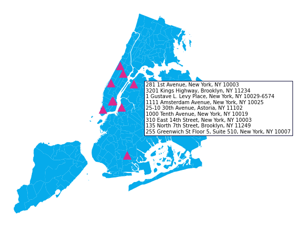

```python
GeocodingExample();
```

## Study Geography Neighborhood Definitions

- Generating Study Geography Neighborhood Definitions from a list of Geography identifiers or Geocoded Addresses:
  - Example Administrative Geographies
    - US Census Blocks
    - US Census Block Groups
    - US Census Tracts
    - US Census ZCTA (ZIP Code Tabulation Area
    - US Census PUMA
    - US County
    - US State
    - US Census MSA\CBSA,
    - Postal ZIP Code
  - Custom Location-Based Neighborhood Geography Definitions
    - Radial (Euclidian) Buffers (ex: 1 km Buffer)
    - Network Distance or Time Based Buffers (ex: 30 min Drive-Time, 0.5 km Walk-Distance),

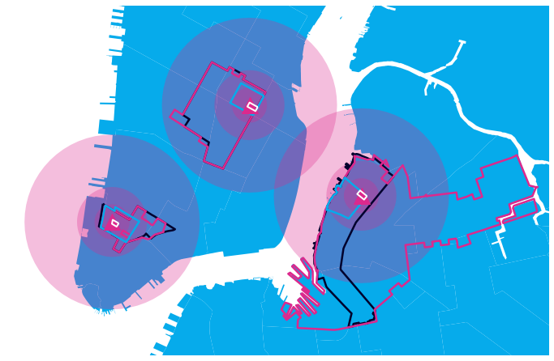

```python
NeighborhoodDefinitions();
```

## Geography Definition Enrichment

Study Geography Neighborhood Definitions Data Enrichment using **Geoprocessing/Spatial Analysis** Methods.

(aggregating geo features to those neighborhood definitions),

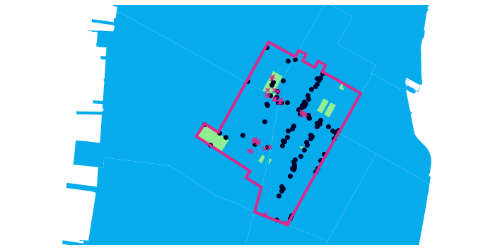

```python
GeographyDefinitionEnrichment();
```

*Example of Geography Definition Enrichment: each of the features can be aggregated and summarized for any given Geography Definition. A standard unit of geography such as a Census Tract can be "enriched." In addition, a geocoded home address with a 1 kilometer radial buffer can also be "enriched."*

### Enrichment Metric Options

#### Geography Definition as Polygon

Polygons may represent shared Administrative geographies such as Census Tract, County, etc. or may be Radial or Network buffers generated from very specific latitude, longitude pairs.

##### Point-in-Polygon Aggregation

Summarize features within a given Geography Definition. If the features have values and other fields, these values can be summarized as well.

##### Near Analysis

Generate metrics to capture a given Geography Definition's proximity or whether it contains a particular type of feature. For example, for a given Census Tract, the euclidean distance to the nearest Hospital may be calculated. If a Hospital is inside the Census Tract it'll be attributed with a distance of zero.

##### Zonal Statistics

Summarize a raster grid cells for a a given Geography Definition.

#### Geography Definition as Points

##### Near Analysis

Generate metrics to capture a given point's euclidean proximity to some other feature. For example, for a given home location, the euclidean distance to the nearest Hospital may be calculated.

## Advanced Geospatial Services

Other Geospatial/Geoporcessing methods for your project.

### Network Analysis/Optimization

### Satellite Imagery

[figure not shown]

*Moisture Index from Sentinel imagery*

[figure not shown]

```python
NetworkAnalysisDisplay();
```

*Example of Network Analysis: network analysis is commonly used in geospatial for routing, such as finding the least cost path when determining driving directions for a given origin/destination pair. Network Analysis can also solve more complex problems like Traveling Salesman or Optimizing Siting Locations for testing centers or services.*

## Map Production and Data Visualization

### Map Production:

- Exploratory Map Visualization
- Publication-Ready Static Maps
- Interactive Plotly and/or Web Maps

### Data Visualization

- Custom Data Visualization

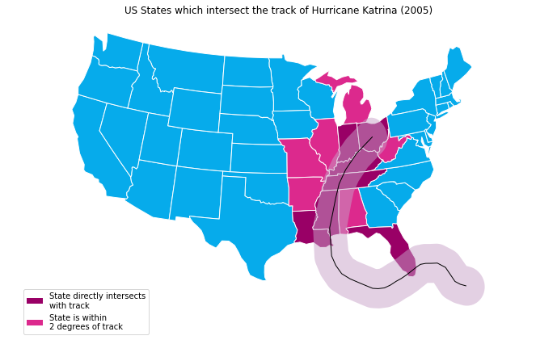

```python
MapProduction();
```

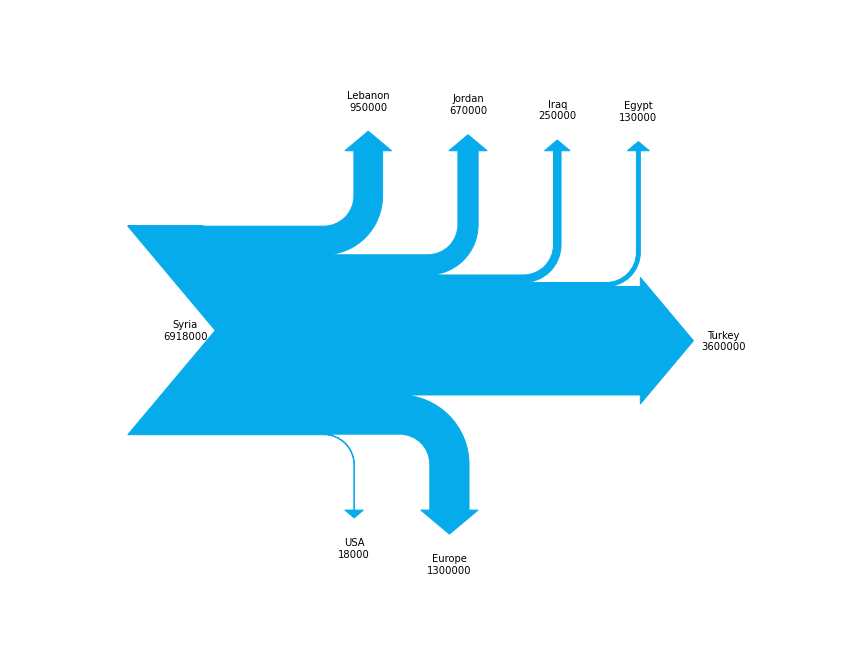

```python
SankeyDataViz();
```

## Data Services

### Data Scraping/Web Mining (automated data collection),

- APIs
- Files on endpoints
- Scraping HTML with BeautifulSoup

### Data Carpentry

- Data Standardization/Normalization
- Database and Data Relationship Management

**Census API Example**

```
def get_census_acs_5yr_tract(api_key, years, out_dir):

    for year in years:
        c = Census(api_key, year=year)

        for state in us.states.STATES:
            download(year, state.name)
```